# Завдання для самоперевірки

## Зміст завдання:

**Частина №1:**

Дослідити дані у файлах Data4-1.csv та Data4-2.csv та виконати завдання:

1. Визначити коефіцієнт кореляції кожного набору.
2. Побудувати графіки розсіювання.
3. Побудувати найбільш підходящу функцію регресії par2=f(par1).

**Частина №2:**

Завантажити дані з файлу Data2.csv.

1. Перевірити за допомогою діаграми розмаху наявність викидів по СО2, використати тест про те, що максимальне значення буде викидом, прибрати викиди, заповнити пропуски.
2. Побудувати лінійну регресію GDP per capita=f(CO2 emission per 1000 person) для вхідного набору та для набору, що логістично нормалізовано.
3. Порахувати значення GDP per capita при CO2 emission per 1000 person = 2. Порівняти результати.
4. Побудувати polar chart для України та довільної іншої європейської країни

## Хід роботи:

### Частина №1:

1. Встановимо необхідні бібліотеки для роботи з масивами, датасетами та графіками:

```python
!pip install numpy pandas matplotlib
```

```python
import numpy as np
import pandas as pd
import matplotlib.pyplot as plt
```

1. Зчитуємо задані набори даних:

```python
df1 = pd.read_csv('data/Data4-1.csv', sep=';', decimal=',', usecols=['Par 1', 'Par 2'])
df2 = pd.read_csv('data/Data4-2.csv', sep=';', decimal=',', usecols=['Par 1', 'Par 2'])
```

1. Розраховуємо матриці кореляції для обох наборів:

```python
df1.corr()
```

|  | Par 1 | Par 2 |
| --- | --- | --- |
| Par 1 | 1.000000 | 0.975459 |
| Par 2 | 0.975459 | 1.000000 |

```python
df2.corr()
```

|  | Par 1 | Par 2 |
| --- | --- | --- |
| Par 1 | 1.000000 | 0.822417 |
| Par 2 | 0.822417 | 1.000000 |

1. Побудуємо графіки розсіювання для візуалізації наборів:

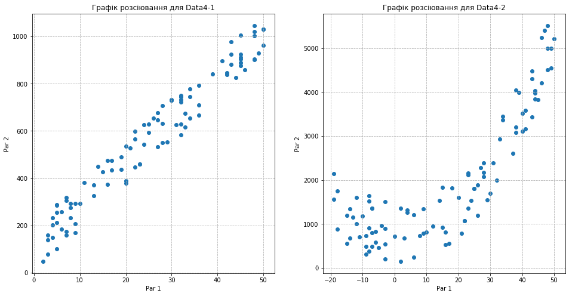

```python
fig, axes = plt.subplots(1, 2, figsize=(16, 8))

dfs = [df1, df2]

for i in range(len(dfs)):
    axes[i].set_title(f'Графік розсіювання для Data4-{i + 1}')
    axes[i].set_xlabel('Par 1')
    axes[i].set_ylabel('Par 2')
    axes[i].grid(linestyle='--')
    axes[i].scatter(dfs[i]['Par 1'], dfs[i]['Par 2'])

plt.show()
```

Як бачимо з графіків, для набору Data4-1 Par2 має лінійну залежність від Par1, а для Data4-2 - нелінійну (можливо, квадратичну).

1. Для побудови регресійних моделей скористаємось бібліотекою scikit-learn:

```python
!pip install -U scikit-learn
```

```python
from sklearn.linear_model import LinearRegression
```

1. Створюємо лінійну регресійну модель для даних Data4-1:

```python
X1 = df1['Par 1'].to_numpy().reshape(-1, 1)
Y1 = df1['Par 2']

reg1 = LinearRegression().fit(X1, Y1)
```

1. Покажемо отриману модель на графіку:

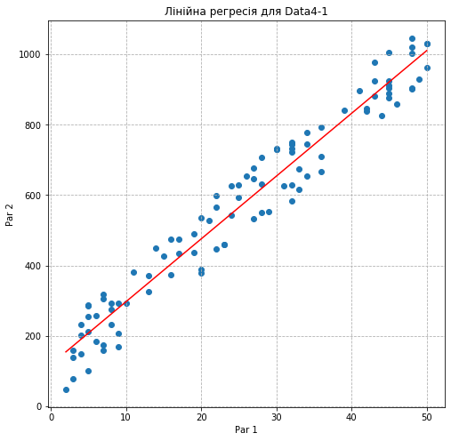

```python
X1_test = np.linspace(X1.min(), X1.max()).reshape(-1, 1)
Y1_pred = reg1.predict(X1_test)

plt.figure(figsize=(8, 8))

plt.title('Лінійна регресія для Data4-1')
plt.xlabel('Par 1')
plt.ylabel('Par 2')
plt.grid(linestyle='--')

plt.scatter(X1, Y1)
plt.plot(X1_test, Y1_pred, color='red')

plt.show()
```

1. Для побудови поліноміальних регресій імпортуємо інструменти для створення поліномів:

```python
from sklearn.preprocessing import PolynomialFeatures
from sklearn.pipeline import make_pipeline
```

1. Створюємо поліноміальну регресійну модель для Data4-2:

```python
X2 = df2['Par 1'].to_numpy().reshape(-1, 1)
Y2 = df2['Par 2']

reg2 = make_pipeline(PolynomialFeatures(degree=2), LinearRegression())
reg2.fit(X2, Y2)
```

1. Покажемо отриману поліноміальну модель на графіку:

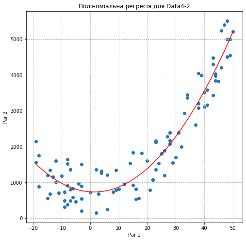

```python
X2_test = np.linspace(X2.min(), X2.max()).reshape(-1, 1)
Y2_pred = reg2.predict(X2_test)

plt.figure(figsize=(8, 8))

plt.title('Поліноміальна регресія для Data4-2')
plt.xlabel('Par 1')
plt.ylabel('Par 2')
plt.grid(linestyle='--')

plt.scatter(X2, Y2)
plt.plot(X2_test, Y2_pred, color='red')

plt.show()
```

### Частина №2:

```python
import scipy.stats as stats
```

1. Зчитуємо заданий набор даних за допомогою Pandas:

```python
df = pd.read_csv('data/Data2.csv', sep=';', decimal=',', encoding='windows-1251')

df
```

|  | Country Name | Region | GDP per capita | Populatiion | CO2 emission | Area |
| --- | --- | --- | --- | --- | --- | --- |
| 0 | Afghanistan | South Asia | 561.778746 | 34656032.0 | 9809.225 | 652860.0 |
| 1 | Albania | Europe & Central Asia | 4124.982390 | 2876101.0 | 5716.853 | 28750.0 |
| 2 | Algeria | Middle East & North Africa | 3916.881571 | 40606052.0 | 145400.217 | 2381740.0 |
| 3 | American Samoa | East Asia & Pacific | 11834.745230 | 55599.0 | NaN | 200.0 |
| 4 | Andorra | Europe & Central Asia | 36988.622030 | 77281.0 | 462.042 | 470.0 |
| ... | ... | ... | ... | ... | ... | ... |
| 212 | Virgin Islands (U.S.) | Latin America & Caribbean | NaN | 102951.0 | NaN | 350.0 |
| 213 | West Bank and Gaza | Middle East & North Africa | 2943.404534 | 4551566.0 | NaN | 6020.0 |
| 214 | Yemen, Rep. | Middle East & North Africa | 990.334774 | 27584213.0 | 22698.730 | 527970.0 |
| 215 | Zambia | Sub-Saharan Africa | 1269.573537 | 16591390.0 | 4503.076 | 752610.0 |
| 216 | Zimbabwe | Sub-Saharan Africa | 1029.076649 | 16150362.0 | 12020.426 | 390760.0 |

217 rows × 6 columns

1. Виправляємо помилку у назви колонки з кількістю населення:

```python
df = df.rename(columns={'Populatiion':'Population'})
```

1. Виправляємо некоректні від'ємні значення колонок з ВВП та площею:

```python
df['GDP per capita'] = abs(df['GDP per capita'])
df['Area'] = abs(df['Area'])
```

1. Виведемо кількість пропущених значень по кожній колонці:

```python
df.isna().sum()
```

```
Country Name       0
Region             0
GDP per capita    27
Population         1
CO2 emission      12
Area               0
dtype: int64
```

1. Побудуємо діаграму розмаху для значень викидів CO2:

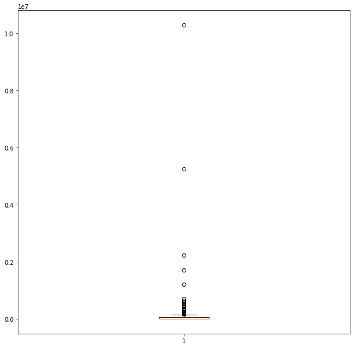

```python
plt.figure(figsize=(10, 10))

plt.boxplot(df[df['CO2 emission'].notnull()]['CO2 emission'])

plt.show()
```

Як можна побачити на діаграмі, в даних присутні викиди (outliers).

1. Застосуємо критерій Граббса для перевірки гіпотези про те, що максимальне значення буде викидом:

```python
# Обчислення критичного значення:
def get_critical_value(size, alpha):
    t_dist = stats.t.ppf(1 - alpha / (2 * size), size - 2)
    numerator = (size - 1) * np.sqrt(np.square(t_dist))
    denominator = np.sqrt(size) * np.sqrt(size - 2 + np.square(t_dist))
    critical_value = numerator / denominator
    return critical_value


# Обчислення критерію:
def grubbs_test(data, alpha=0.05):
    g_calculated = np.abs(data - np.mean(data)).max() / np.std(data)
    g_critical = get_critical_value(len(data), alpha)
    print(f'Значення критерію Граббса: {g_calculated}, критичне значення: {g_critical}')
    return g_calculated, g_critical


grubbs_test(df['CO2 emission'])
```

```
Значення критерію Граббса: 12.178966101102302, критичне значення: 3.629864824961855
```

```
(12.178966101102302, 3.629864824961855)
```

1. Приберемо викиди з даних:

```python
# Розраховуємо інтервал для валідних даних:
# [25% – 1.5 * (75% – 25%), 75% + 1.5 * (75% – 25%)]
def calc_valid_range(data):
    complete_cases = data[~data.isna()]
    q25, q75 = complete_cases.quantile([0.25, 0.75])['CO2 emission']
    qr = q75 - q25
    return (q25 - 1.5 * qr, q75 + 1.5 * qr)

rng = calc_valid_range(df)

# Дані без викидів:
df_wo_outliers = df[((df['CO2 emission'] >= rng[0]) & (df['CO2 emission'] <= rng[1])) | df['CO2 emission'].isna()]
```

1. Заповнюємо пропущені значення середніми:

```python
df = df.fillna(df.mean())
```

1. Створимо колонку викидів СО2 на 1000 осіб:

```python
df['CO2 emission per 1000'] = df['CO2 emission'] / df['Population'] * 1000
```

1. Створимо лінійну регресію, де предиктором є кількість викидів СО2 на 1000 осіб, цільовою змінною - ВВП на душу населення:

```python
reg = LinearRegression().fit(df['CO2 emission per 1000'].to_numpy().reshape(-1, 1), df['GDP per capita'])
```

1. Візуалізуємо модель на графіку:

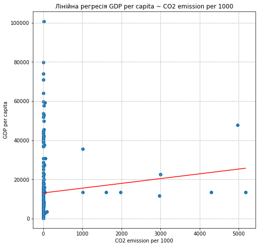

```python
CO2_vals = np.linspace(df['CO2 emission per 1000'].min(), df['CO2 emission per 1000'].max()).reshape(-1, 1)
GDP_pred = reg.predict(CO2_vals)

plt.figure(figsize=(8, 8))

plt.title('Лінійна регресія GDP per capita ~ CO2 emission per 1000')
plt.xlabel('CO2 emission per 1000')
plt.ylabel('GDP per capita')
plt.grid(linestyle='--')

plt.scatter(df['CO2 emission per 1000'], df['GDP per capita'])
plt.plot(CO2_vals, GDP_pred, color='red')

plt.show()
```

1. Логістично нормалізуємо вхідні дані:

```python
def lognorm(data):
    mean = np.mean(data)
    std = np.std(data)
    norm_data = 1 / (1 + np.exp(mean - data) / (std + 0.0000001))
    return norm_data


norm_co2 = lognorm(df['CO2 emission per 1000'].to_numpy())
```

1. Побудуємо лінійну регресію для нормалізованих вхідних даних:

```python
reg_norm = LinearRegression().fit(norm_co2.reshape(-1, 1), df['GDP per capita'])
```

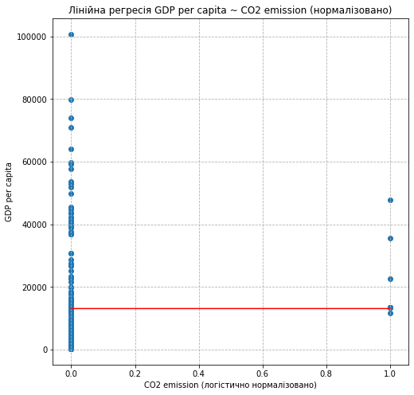

```python
CO2_norm_vals = np.linspace(norm_co2.min(), norm_co2.max()).reshape(-1, 1)
GDP_norm_pred = reg.predict(CO2_norm_vals)

plt.figure(figsize=(8, 8))

plt.title('Лінійна регресія GDP per capita ~ CO2 emission (нормалізовано)')
plt.xlabel('CO2 emission (логістично нормалізовано)')
plt.ylabel('GDP per capita')
plt.grid(linestyle='--')

plt.scatter(norm_co2, df['GDP per capita'])
plt.plot(CO2_norm_vals, GDP_norm_pred, color='red')

plt.show()
```

1. Використаємо отримані моделі для обрахування значення GDP per capita при CO2 emission per 1000 person = 2:

```python
# Ненормалізований вхід:
reg.predict(np.array([[2,]]))
```

```
array([13145.26502395])
```

```python
# Нормалізований вхід:
reg_norm.predict(lognorm(np.array([[2,]])))
```

```
array([13137.44089306])
```

1. Побудуємо polar chart для України та довільної іншої європейської країни:

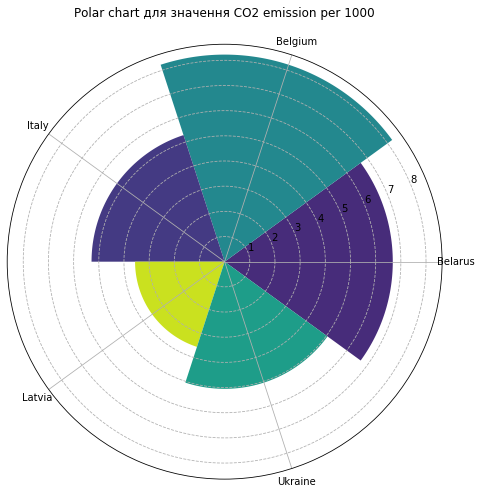

```python
fig = plt.figure(figsize=(8, 8))
ax = fig.add_subplot(111, polar=True)

sample = df[df['Country Name'].isin(['Ukraine', 'Italy', 'Belgium', 'Latvia', 'Belarus'])]
N = len(sample)

np.random.seed(196800)
theta = np.arange(0, 2 * np.pi, 2 * np.pi / N)
bars = ax.bar(theta, sample['CO2 emission per 1000'], 2 * np.pi / N, color=plt.cm.viridis(np.random.rand(N)))

ax.set_title('Polar chart для значення CO2 emission per 1000')
ax.set_xticks(theta)
ax.set_xticklabels(sample['Country Name'])
ax.yaxis.grid(True, linestyle='--')
plt.show()
```